# Homogenized Observation Data - CanHom & AHCCD

## Summary Description

The Adjusted and Homogenized Canadian Climate Data (AHCCD) are climate station datasets of quality-controlled and homogenized historical climate data from Environment and Climate Change Canada (ECCC). They provide long-term station-based observations for temperature, precipitation, wind and atmospheric pressure across Canada. The datasets incorporate adjustments to the historical station data for non-climatic factors (e.g., station relocations, site exposure, instrumentation changes, observer, observing procedures) to ensure consistency and reliability. AHCCD data was developed for climate research, climate change studies and trend analysis. The latest versions of homogenized Canadian climate data have been published under the name Canadian Homogenized Surface Air Temperature (CanHomT V4) (Wan *et al.* (2025)). Publication of updated Canadian Homogenized Precipitation (CanHomP V2, Wang & Feng (2026)) and Canadian Homogenized Wind Speed data (CanHomW V2, Wang *et al.* (2025)) shall follow. Note that Zwiers & Wang (2026) found inconsistency in CanHomT V4. Detailed descriptions of the AHCCD/CanHom datasets are listed under the Dataset Characteristics below.

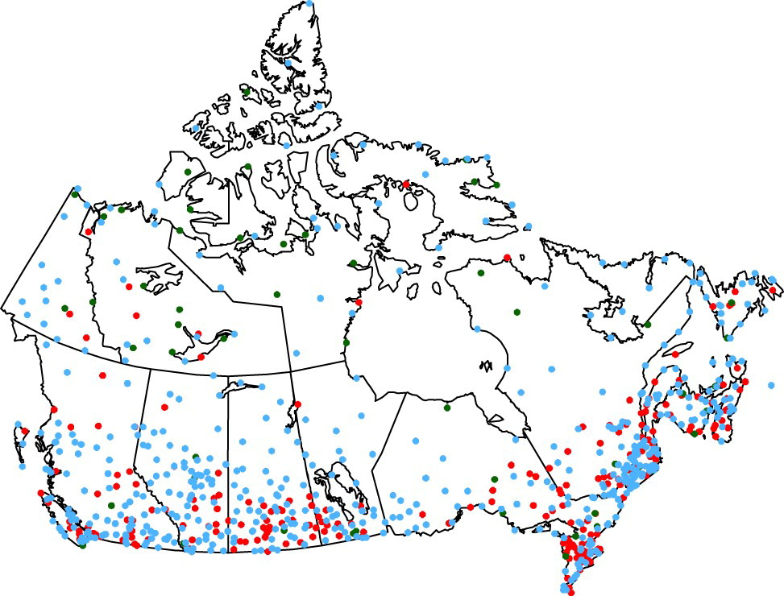

AHCCD Temperature Stations with starting dates prior to 1990 (blue), starting dates from 1990 (green), and stations closed but with more than 30 years of data (red) (figure from Vincent *et al.* (2020)).

## Dataset Characteristics

- **Current version:** The dataset is updated irregularly with the most recent data (although the website suggests annual updates).
- **Available variables:** temperature, precipitation, wind, station level pressure, sea level pressure (see variables section below)
- **Temporal coverage:** Varies per station and variable, data availability ranging between 1840 and 2023
- **Temporal resolution:** Annual, seasonal, monthly and daily values
- **Spatial coverage:** Stations across all Canadian provinces and territories
- **Spatial resolution:** Point locations across Canada
- **Data type**: Historical observations from ECCC climate stations, adjusted and homogenized using statistical methods
- **Data format:** netCDF, CSV, GeoJSON depending on data access portal.
- **Web references:**  
  [Canadian Homogenized Surface Air Temperature (CanHomT V4)](https://open.canada.ca/data/en/dataset/542b90f7-ab39-452c-be5c-2afebdc4724c) [Adjusted and Homogenized Canadian Climate Data (AHCCD)](https://open.canada.ca/data/en/dataset/9c4ebc00-3ea4-4fe0-8bf2-66cfe1cddd1d)  
  [Technical documentation: Adjusted and homogenized Canadian climate data (AHCCD)](https://www.canada.ca/en/environment-climate-change/services/climate-change/canadian-centre-climate-services/display-download/technical-documentation-adjusted-climate-data.html)
- **References:**  
  **AHCCD**:
  - Temperature: Vincent *et al.* (2020)
  - Precipitation: Mekis & Vincent (2011)

  **CanHom**:
  - Temperature: Wan *et al.* (2025) (CanHomT)
  - Precipitation: Wang & Feng (2026) (CanHomP)
  - Wind: Wang *et al.* (2025) (CanHomW)
- **Contact:** [Climate Services Support Desk](https://climate-change.canada.ca/support-desk), [ClimatData.ca Online Support](https://climatedata.ca/feedback/)

## When to use AHCCD & CanHom

- When you need information about **past climate**.
- When you don’t mind **temporal or spatial discontinuities**.
- When you need **near-surface temperature** or **precipitation** data.
- When you need information about **extremes**.
- When you need to detect **historical trends**.
- When you need to **validate reanalysis** data.
- When you need to establish **local thresholds** or **reference climatologies**.

## Strengths and Limitations

### Key Strengths of AHCCD & CanHom

| Strength | Description |
| --- | --- |
| **Homogenized time series** | Adjustments remove artificial shifts due to non-climatic influences, thus allowing more accurate trend analysis. |
| **Long-term coverage**. | Long term data containing many stations with over 100 years of record. |
| **National consistency** | Standardized methodologies applied across the Canadian network. |
| **Data source for ECCC’s climate indicators** | Used in the development of [Canadian climate change indicators](https://www.canada.ca/en/environment-climate-change/services/environmental-indicators/climate.html) and official climate assessments. |

### Limitations of AHCCD & CanHom

[output not shown]

## Expert Guidance

**None(click to expand)**

Environment and Climate Change Canada (ECCC) produces the Adjusted and Homogenized Canadian Climate Data (AHCCD) for use in climate research and climate change studies and the data have been used in the production of climate trends (Vincent *et al.* (2015), Vincent *et al.* (2018)). The data are collected from Reference Climate Stations and some Canadian Aviation Weather Service stations. The AHCCD stations keep the same IDs as the Meteorological Service of Canada (MSC) stations to facilitate comparison. Note that the [governments AHCCD web site](https://www.canada.ca/en/environment-climate-change/services/climate-change/science-research-data/climate-trends-variability/adjusted-homogenized-canadian-data.html) and the [AHCCD Technical Documentation](https://www.canada.ca/en/environment-climate-change/services/climate-change/canadian-centre-climate-services/display-download/technical-documentation-adjusted-climate-data.html#toc5) mention that AHCCD data should not be used for legal purposes since they are different from official MSC in situ records.

The non-climatic shifts in tempertature data are identified by statistically comparing adjacent stations. Station metadata are investigated to understand non-climatic causes and determine a corrective measure if a shift has been identified. A recurring adjustment is related to the change in observing time at principal stations in 1961. The correction of the temperature record results in a slightly stronger warming in the homogenized dataset than the unadjusted data: For southern Canada this trend changed from 1.32° to 1.62°C for 1900–2018, with a smaller change for all of Canada (Vincent *et al.* (2020)). An analysis of the Fourth Generation of homogenized surface air temperature (CanHomT V4) by Zwiers & Wang (2026) revealed differences that lead to sustationally greater warming in the dataset when compared to other sources. An update of this version is pending as of this writing.

Precipitation data correction accounts for a number of known errors in precipitation measurements, such as underestimation of actually gauged precipitation and limits to the minimum measurable amount. Snow measurements adjust for varying snow density depending on geographical location. Updates of historical adjusted precipitation has been interrupted since Autumn 2017. This hiatus is related to the integration of manual observations to an increasingly automated station network. Updates are planned to be resumed, but no time has been specified. Check for update on this prior to publication!

Monthly datasets for Precipitation (Wang & Feng (2026)) and for Wind (Wang *et al.* (2025)) have been published. Qian *et al.* (2025) use CanHomT and CanHomP to derive observed changes in Canada’s snowfall. Wang & Feng (2026) analyze trends in extremme precipitation indices using the next generation of Canadian Homogenized Daily Precipitation, CanHomP V2, however the data are not published at the time of this writing.Check for update on data availablility of precip prior to publication!

For wind speed adjustments, the key measure is the standardization of the measuring height at 10m above ground based on meta data and the measurement instrument setup. Furthermore, non-climatic causes of shifts in wind speed are identified by comparing monthly means at stations to modeled monthly means.

The non-climatic shifts that are corrected in AHCCD sea level pressure and station pressure data are related to station elevation, station relocation and errors during digitization of paper records. The correction process also scans for unusually high or low values, sudden extremes or physically implausible pressure changes.

##### Version Overview (as of 2026)

[output not shown]

More details on the methodology can be found in the [AHCCD Technical Documentation](https://www.canada.ca/en/environment-climate-change/services/climate-change/canadian-centre-climate-services/display-download/technical-documentation-adjusted-climate-data.html) and the references therein.

## Variables available in AHCCD & CanHom

*For details click on variable group to uncollapse*

**NoneTemperature**

###### Daily temperature values

- Minimum temperature [˚C]
- Maximum temperature [˚C]
- Mean temperature [˚C]
- >330 locations in Canada

For more details see the [website on daily AHCCD data](https://open.canada.ca/data/en/dataset/d6813de6-b20a-46cc-8990-01862ae15c5f)

###### Monthly, seasonal, and annual mean

- Minimum temperature [˚C]
- Maximum temperature [˚C]
- Mean temperature [˚C]
- 780 locations in Canada

For more details see the [AHCCD Technical Documentation](https://www.canada.ca/en/environment-climate-change/services/climate-change/canadian-centre-climate-services/display-download/technical-documentation-adjusted-climate-data.html) and the [Adjusted and homogenized Canadian climate data web page for temperature data](https://www.canada.ca/en/environment-climate-change/services/climate-change/science-research-data/climate-trends-variability/adjusted-homogenized-canadian-data/surface-air-temperature.html) and references therein.

**NonePrecipitation**

###### Daily precipitation values

- Daily liquid precipitation (rain) [mm/period]
- Daily solid precipitation (snow) [mm/period]
- Daily total precipitation (rain and snow) [mm/period]
- >460 locations in Canada

For more details see the [website on daily AHCCD data](https://open.canada.ca/data/en/dataset/d6813de6-b20a-46cc-8990-01862ae15c5f)

###### Monthly, seasonal, and annual mean

- Liquid precipitation (rain) [mm/period]
- Solid precipitation (snow) [mm/period]
- Total precipitation (rain and snow) [mm/period]
- 467 locations in Canada

For more details see the [AHCCD Technical Documentation](https://www.canada.ca/en/environment-climate-change/services/climate-change/canadian-centre-climate-services/display-download/technical-documentation-adjusted-climate-data.html) and the [Adjusted and homogenized Canadian climate data web page for precipitation data](https://www.canada.ca/en/environment-climate-change/services/climate-change/science-research-data/climate-trends-variability/adjusted-homogenized-canadian-data/precipitation.html) and references therein.

**NoneWind**

###### Monthly, seasonal and annual means of hourly wind speed

- Wind speed [m/s]
- Evaluated at standard 10 metre level
- 156 locations in Canada

For more details see the [AHCCD Technical Documentation](https://www.canada.ca/en/environment-climate-change/services/climate-change/canadian-centre-climate-services/display-download/technical-documentation-adjusted-climate-data.html) and the [Adjusted and homogenized Canadian climate data web page for wind speed data](https://www.canada.ca/en/environment-climate-change/services/climate-change/science-research-data/climate-trends-variability/adjusted-homogenized-canadian-data/surface-wind-speed.html) and references therein.

**NonePressure**

###### Monthly, seasonal and annual means of hourly measurements

- Station level pressure [Pa]
- Sea Level pressure [Pa]
- 626 locations in Canada

For more details see the [AHCCD Technical Documentation](https://www.canada.ca/en/environment-climate-change/services/climate-change/canadian-centre-climate-services/display-download/technical-documentation-adjusted-climate-data.html) and the [Adjusted and homogenized Canadian climate data web page for wind speed data](https://www.canada.ca/en/environment-climate-change/services/climate-change/science-research-data/climate-trends-variability/adjusted-homogenized-canadian-data/surface-pressure.html) and references therein.

## Data Access

Daily AHCCD station data can be found on [ClimateData.ca](https://climatedata.ca/download/#ahccd-download) or downloaded via the [Climate Data Extraction Tool](https://climate-change.canada.ca/climate-data/#/adjusted-station-data) (Monthly, seasonal and annual AHCCD station data). A collection of all daily AHCCD station data in a single [netCDF](https://www.unidata.ucar.edu/software/netcdf/) file is available on [PAVICS](https://pavics.ouranos.ca/datasets.html#b).

## References

**(click to expand)**

Mekis, É., & Vincent, L. A. (2011). [An overview of the second generation adjusted daily precipitation dataset for trend analysis in canada](https://doi.org/10.1080/07055900.2011.583910). *Atmosphere-Ocean*, **49**(2), 163–177.

Qian, B., Wang, X. L., Zwiers, F. W., & Feng, Y. (2025). [Observed changes in canada’s snowfall as inferred from precipitation and daily mean temperatures](https://doi.org/10.1080/07055900.2025.2586566). *Atmosphere-Ocean*, **0**(0), 1–15.

Vincent, L. A., Hartwell, M. M., & and, X. L. W. (2020). [A third generation of homogenized temperature for trend analysis and monitoring changes in canada’s climate](https://doi.org/10.1080/07055900.2020.1765728). *Atmosphere-Ocean*, **58**(3), 173–191.

Vincent, L. A., Zhang, X., Brown, R. D., … Wang, X. L. (2015). [Observed trends in canada’s climate and influence of low-frequency variability modes](https://doi.org/10.1175/JCLI-D-14-00697.1). *Journal of Climate*, **28**(11), 4545–4560.

Vincent, L. A., Zhang, X., Mekis, É., Wan, H., & and, E. J. B. (2018). [Changes in canada’s climate: Trends in indices based on daily temperature and precipitation data](https://doi.org/10.1080/07055900.2018.1514579). *Atmosphere-Ocean*, **56**(5), 332–349.

Wan, H., Spassiani, A. C., & Vincent, L. A. (2025). [Canada’s fourth generation of homogenized surface air temperature and its trends for 1948–2023](https://doi.org/10.1080/07055900.2025.2516796). *Atmosphere-Ocean*, **63**(4), 223–240.

Wan, H., Wang, X. L., & Swail, V. R. (2007). [A quality assurance system for canadian hourly pressure data](https://doi.org/10.1175/2007JAMC1484.1). *Journal of Applied Meteorology and Climatology*, **46**(11), 1804–1817.

Wan, H., Wang, X. L., & Swail, V. R. (2010). [Homogenization and trend analysis of canadian near-surface wind speeds](https://doi.org/10.1175/2009JCLI3200.1). *Journal of Climate*, **23**(5), 1209–1225.

Wang, X. L., & Feng, Y. (2026). [Observed trends in precipitation extreme indices as inferred from a homogenized daily precipitation dataset for canada](https://doi.org/10.1016/j.wace.2026.100860). *Weather and Climate Extremes*, **51**, 100860.

Wang, X. L., Feng, Y., Isaac, V., Zwiers, F. W., Vincent, L. A., & Hartwell, M. M. (2025). [Observed surface wind speed trends inferred from homogenized in situ data and reanalysis datasets](https://doi.org/10.1080/07055900.2025.2570920). *Atmosphere-Ocean*, **0**(0), 1–17.

Zwiers, F. W., & Wang, X. L. (2026). [Comment on “canada’s fourth generation of homogenized surface air temperature and its trends for 1948–2023″ by wan et al. (2025)](https://doi.org/10.1080/07055900.2026.2657986). *Atmosphere-Ocean*, **0**(0), 1–5.